# Exploratory Data Analysis of Fashion Retail Sales and Returns

## Project Objective

Conducted end-to-end Exploratory Data Analysis (EDA) on a Fashion Boutique dataset using Python (Pandas, Matplotlib, Seaborn) to derive actionable business insights. Performed data cleaning, preprocessing, and statistical analysis to evaluate brand performance, product distribution, pricing trends, and inventory patterns. Developed meaningful visualizations to identify key trends and support data-driven decision-making, demonstrating strong analytical, problem-solving, and business interpretation skills.

## Data Loading and Initial Overview

```python
import numpy as np
import pandas as pd
import matplotlib.pyplot as plt
import seaborn as sns
```

```python
df = pd.read_csv('fashion_boutique_dataset.csv')
```

```python
df.head()
```

|  | product_id | category | brand | season | size | color | original_price | markdown_percentage | current_price | purchase_date | stock_quantity | customer_rating | is_returned | return_reason |
| --- | --- | --- | --- | --- | --- | --- | --- | --- | --- | --- | --- | --- | --- | --- |
| 0 | FB000001 | Outerwear | Zara | Spring | XL | Red | 196.01 | 0.0 | 196.01 | 2025-07-05 | 37 | 3.0 | False | NaN |
| 1 | FB000002 | Tops | Uniqlo | Winter | L | Pink | 119.64 | 0.0 | 119.64 | 2025-08-06 | 2 | 2.5 | False | NaN |
| 2 | FB000003 | Accessories | Uniqlo | Winter | NaN | Black | 33.80 | 0.0 | 33.80 | 2025-08-06 | 22 | 4.3 | False | NaN |
| 3 | FB000004 | Shoes | Uniqlo | Spring | XL | Black | 75.36 | 0.0 | 75.36 | 2025-07-07 | 48 | 2.6 | False | NaN |
| 4 | FB000005 | Tops | Banana Republic | Winter | XL | Black | 105.02 | 0.0 | 105.02 | 2025-08-06 | 10 | NaN | False | NaN |

```python
df.shape
```

```
(2176, 14)
```

Dataset has 2176 rows and 14 columns

```python
df.columns
```

```
Index(['product_id', 'category', 'brand', 'season', 'size', 'color',
       'original_price', 'markdown_percentage', 'current_price',
       'purchase_date', 'stock_quantity', 'customer_rating', 'is_returned',
       'return_reason'],
      dtype='object')
```

Dataset has 14 columns such as

- Product ID
- Category
- Brand
- Season
- Size
- Color
- Original Price
- Markdown Percentage
- Current Price
- Purchase Date
- Stock Quantity
- Customer Rating
- Is returned
- Return Reason

```python
df.info()
```

```
<class 'pandas.core.frame.DataFrame'>
RangeIndex: 2176 entries, 0 to 2175
Data columns (total 14 columns):
 #   Column               Non-Null Count  Dtype
---  ------               --------------  -----
 0   product_id           2176 non-null   object
 1   category             2176 non-null   object
 2   brand                2176 non-null   object
 3   season               2176 non-null   object
 4   size                 1685 non-null   object
 5   color                2176 non-null   object
 6   original_price       2176 non-null   float64
 7   markdown_percentage  2176 non-null   float64
 8   current_price        2176 non-null   float64
 9   purchase_date        2176 non-null   object
 10  stock_quantity       2176 non-null   int64
 11  customer_rating      1814 non-null   float64
 12  is_returned          2176 non-null   bool
 13  return_reason        320 non-null    object
dtypes: bool(1), float64(4), int64(1), object(8)
memory usage: 223.3+ KB
```

From above information the dataset consist missing values.Size,customer rating and return_reason columns has null values.Similarly data type of purchase_date column is object, so it converts to date format.

```python
df.describe()
```

|  | original_price | markdown_percentage | current_price | stock_quantity | customer_rating |
| --- | --- | --- | --- | --- | --- |
| count | 2176.000000 | 2176.000000 | 2176.000000 | 2176.000000 | 1814.000000 |
| mean | 97.200340 | 12.144715 | 85.499596 | 24.937960 | 2.986604 |
| std | 51.637345 | 18.417786 | 50.091354 | 14.451387 | 1.159722 |
| min | 15.140000 | 0.000000 | 7.290000 | 0.000000 | 1.000000 |
| 25% | 57.872500 | 0.000000 | 46.845000 | 13.000000 | 2.000000 |
| 50% | 88.600000 | 0.000000 | 74.885000 | 25.000000 | 3.000000 |
| 75% | 127.630000 | 22.425000 | 112.865000 | 37.000000 | 4.000000 |
| max | 249.980000 | 59.900000 | 249.980000 | 50.000000 | 5.000000 |

1. Pricing Analysis
- Average Original Price = 97.20
- Average Current Price = 85.5
- This shows an overall price reduction trend.
- Minimum price is 7.29, maximum price is 249.98, indicating a wide price range.
- The standard deviation (~50) suggests high price variability among products.
2. Markdown Percentage
- Average markdown: 12.14%
- 25% and 50% percentiles are 0%, meaning at least half of the products have no discount.
- Maximum markdown goes up to 59.9%, showing some heavily discounted products.
- High standard deviation (18.41) indicates discount rates vary significantly.
3. Stock Quantity
- Average stock: ~25 units
- Stock ranges from 0 to 50 units
- 25% of products have stock ≤ 13 units.
- Some products are out of stock (0 quantity).
4. Customer Rating
- Average rating: 2.99 (~3 stars)
- Ratings range from 1 to 5
- Majority of ratings fall between 2 and 4
- Standard deviation (1.15) shows moderate variation in customer satisfaction.

## Data Pre-processing

```python
df.isnull().sum()
```

```
product_id                0
category                  0
brand                     0
season                    0
size                    491
color                     0
original_price            0
markdown_percentage       0
current_price             0
purchase_date             0
stock_quantity            0
customer_rating         362
is_returned               0
return_reason          1856
dtype: int64
```

```python
df['purchase_date'] = pd.to_datetime(df['purchase_date'])
```

Data type converts to date time format

```python
df.duplicated().sum()
```

```
np.int64(0)
```

No duplicated values

```python
df.dtypes
```

```
product_id                     object
category                       object
brand                          object
season                         object
size                           object
color                          object
original_price                float64
markdown_percentage           float64
current_price                 float64
purchase_date          datetime64[ns]
stock_quantity                  int64
customer_rating               float64
is_returned                      bool
return_reason                  object
dtype: object
```

```python
df['size'] = df['size'].fillna('No size (Accessories)')
```

```python
df['customer_rating'] = df['customer_rating'].fillna(df['customer_rating'].mean().round(2))
```

In customer_rating column's null value is handle with average of that column

```python
df['return_reason'] = df['return_reason'].fillna('Not returned')
```

Null values in the return_reason column is fill with Not retuned

```python
df.isnull().sum()
```

```
product_id             0
category               0
brand                  0
season                 0
size                   0
color                  0
original_price         0
markdown_percentage    0
current_price          0
purchase_date          0
stock_quantity         0
customer_rating        0
is_returned            0
return_reason          0
dtype: int64
```

Now,the dataset has no missing values

```python
df['discount_amount'] = df['original_price'] - df['current_price']
```

Created a 'Dicount Amount' column from existing columns

```python
df['revenue'] = df['current_price'] * df['stock_quantity']
```

Created 'revenue' column

## Exploratory Data Analysis (EDA)

### 1. Brand-wise Product Distribution

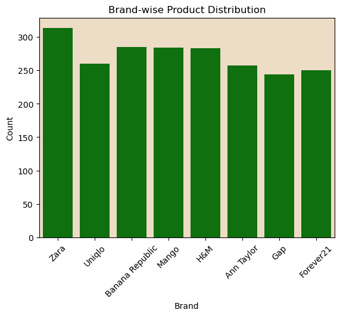

```python
sns.countplot(x='brand', data=df, color='g')
plt.title('Brand-wise Product Distribution')
plt.xlabel('Brand')
plt.ylabel('Count')
plt.xticks(rotation=45)
plt.gca().set_facecolor('#EDDCC6')
plt.show()
```

- Top Performer: Zara (highest product count, >300)
- Lowest Performer: Gap (<250 products)
- High-Volume Cluster: Banana Republic, Mango, H&M (~300 products each)
- Mid-Range Brands: Uniqlo, Ann Taylor, Forever21 (250-260 products each)
- Overall: All brands have a significant product count (240-320), with no massive disparities.

### 2. Season-wise Product Distribution

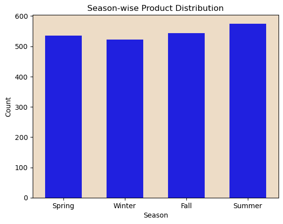

```python
sns.countplot(x='season', data=df, width = 0.6, color = 'b')
plt.title('Season-wise Product Distribution')
plt.xlabel('Season')
plt.ylabel('Count')
plt.gca().set_facecolor('#EDDCC6')
plt.show()
```

- Summer is the season with the largest product distribution, having a count of nearly 600 items.
- Winter has the lowest product count, with just over 500 items.
- The overall product distribution is relatively balanced across all four seasons, with no single season having drastically fewer products than the others.

### 3. Color-wise Product Distribution

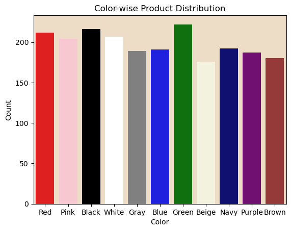

```python
plt.gca().set_facecolor('#EDDCC6')
sns.countplot(data=df, x='color', hue='color', legend=False, palette=list(df['color'].unique()))
plt.title('Color-wise Product Distribution')
plt.xlabel('Color')
plt.ylabel('Count')
plt.show()
```

- Top Color: Green (highest products, >220)
- High-Volume Colors: Black, Red, White (>200 products each)
- Least Popular: Beige (<180 products)
- Mid-Range Colors: Blue, Navy, Purple, Gray, Pink (190-205 products each)
- Balanced Inventory: Relatively even distribution, with only ~45 units difference between most and least frequent colors

### 4. Size-wise Product Distribution

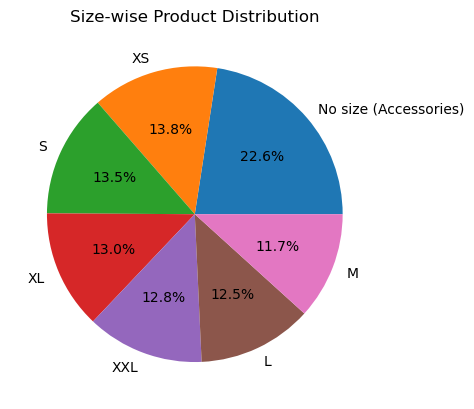

```python
size_dist = df['size'].value_counts()
plt.pie(size_dist, labels=size_dist.index, autopct='%1.1f%%')
plt.title('Size-wise Product Distribution')
plt.show()
```

- Dominant Segment: "No size (Accessories)" (22.6% of products)
- Even Sizing: XS to XXL sizes are balanced (11.7-13.8% each)
- Most Common Size: XS (13.8%)
- Least Common Size: M (11.7%)
- Inclusive Sizing: XL (13.0%) and XXL (12.8%) have a strong presence

### 5. Original Price vs Current Price

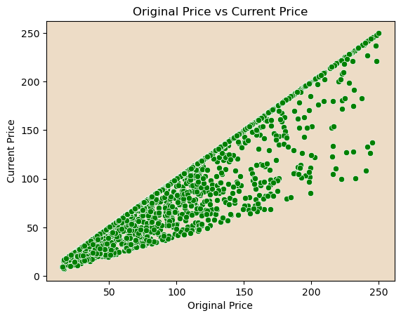

```python
sns.scatterplot(x='original_price', y='current_price', data=df, color='g')
plt.title('Original Price vs Current Price')
plt.xlabel('Original Price')
plt.ylabel('Current Price')
plt.gca().set_facecolor('#EDDCC6')
plt.show()
```

- There is a strong positive correlation between original price and current price, indicating that more expensive items remain more expensive.
- Many data points lie perfectly on the line of equality, suggesting numerous items are sold at their original price without a discount.
- A significant number of items have a current price lower than their original price, indicating the presence of discounts.

### 6. Return Rate by Category

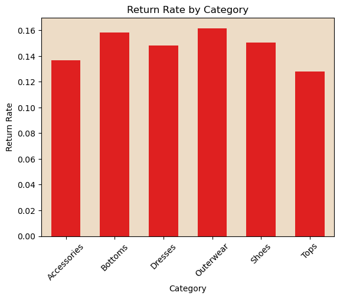

```python
return_rate = df.groupby('category')['is_returned'].mean().reset_index()
sns.barplot(x='category', y='is_returned', data=return_rate, color='r', width = 0.6)
plt.title('Return Rate by Category')
plt.xlabel('Category')
plt.ylabel('Return Rate')
plt.xticks(rotation=45)
plt.gca().set_facecolor('#EDDCC6')
plt.show()
```

- Highest Return Rate: Outerwear (16.2%)
- Lowest Return Rate: Tops (12.8%)
- High-Return Categories: Bottoms (~16%)
- Mid-Range: Dresses and Shoes (~14.8-15%)
- Consistent Experience: All categories have return rates between 13-16%, with no major outliers

### 7. Price Distribution

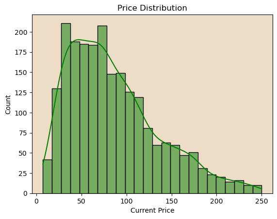

```python
sns.histplot(df['current_price'], kde=True, color='g')
plt.title('Price Distribution')
plt.xlabel('Current Price')
plt.ylabel('Count')
plt.gca().set_facecolor('#EDDCC6')
plt.show()
```

### 8. Customer Rating Distribution

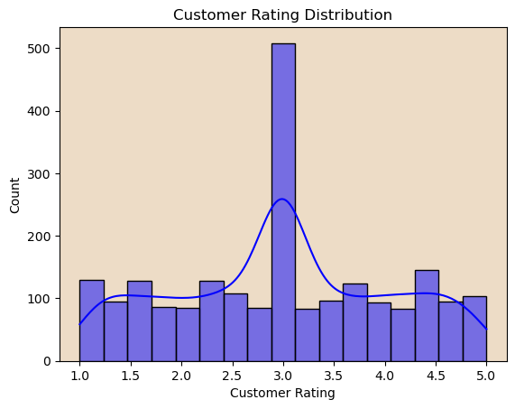

```python
sns.histplot(df['customer_rating'], kde=True, color= 'b' )
plt.title('Customer Rating Distribution')
plt.xlabel('Customer Rating')
plt.ylabel('Count')
plt.gca().set_facecolor('#EDDCC6')
plt.show()
```

- The most common customer rating is 3.0, which has the highest frequency count of approximately 500.
- Ratings are generally distributed across the entire 1.0 to 5.0 scale, with peaks around 1.0, 2.5, 3.0, and 4.5.
- The distribution is relatively balanced, suggesting a wide range of customer satisfaction levels across products.

### 9. Markdown Percentage vs Return Rate

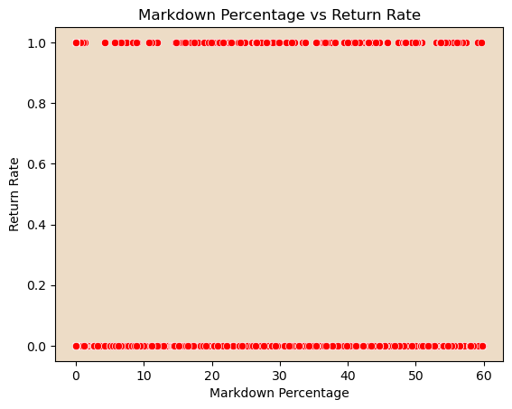

```python
sns.scatterplot(x='markdown_percentage', y='is_returned', data=df, color='r')
plt.title('Markdown Percentage vs Return Rate')
plt.xlabel('Markdown Percentage')
plt.ylabel('Return Rate')
plt.gca().set_facecolor('#EDDCC6')
plt.show()
```

- The chart shows no clear visual correlation between the markdown percentage and the return rate; the data points are scattered across either 0.0 or 1.0 return rates for various markdown percentages.
- Products either have a return rate of effectively 0% or 100%, and this status does not seem to change based on how much the item is marked down.

### 10. Correlation Matrix

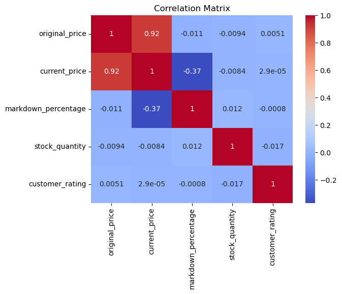

```python
corr = df[['original_price', 'current_price', 'markdown_percentage', 'stock_quantity', 'customer_rating']].corr()
sns.heatmap(corr, annot=True, cmap='coolwarm')
plt.title('Correlation Matrix')
plt.show()
```

- There is a very strong positive correlation (0.92) between original price and current price.
- Markdown percentage has a moderate negative correlation with current price (-0.37) and no significant correlation with customer rating (-0.0008).
- Stock quantity and customer rating have very weak or negligible correlations with all price and markdown metrics.

### 11. Stock Quantity by Category and Size

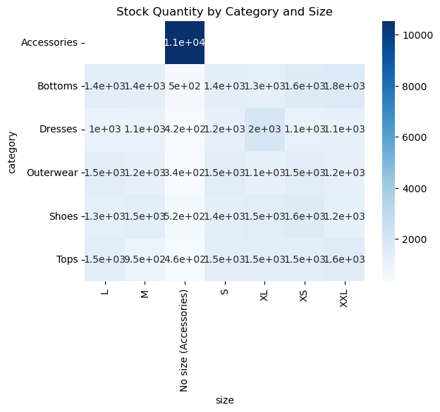

```python
sns.heatmap(df.pivot_table(index='category', columns='size', values='stock_quantity', aggfunc='sum'), annot=True, cmap='Blues')
plt.title('Stock Quantity by Category and Size')
plt.show()
```

### 12. Revenue by Category

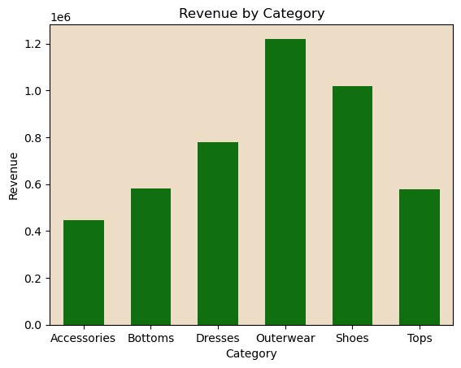

```python
category_revenue = df.groupby('category')['revenue'].sum().reset_index()
sns.barplot(data = category_revenue, x= 'category', y='revenue', color = 'g', width = 0.6)
plt.title('Revenue by Category')
plt.xlabel('Category')
plt.ylabel('Revenue')
plt.gca().set_facecolor('#EDDCC6')
plt.show()
```

- Outerwear generates the highest revenue, exceeding 1.2 million units of currency.
- Accessories bring in the lowest revenue, at less than 0.5 million.
- Shoes are the second-highest revenue generator, making about 1.0 million.

### 13. Discount Amount Distribution

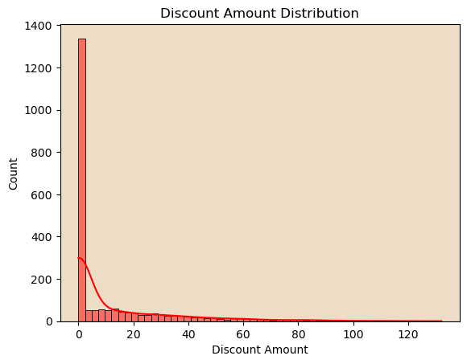

```python
sns.histplot(df['discount_amount'], kde=True, color ='r')
plt.title('Discount Amount Distribution')
plt.xlabel('Discount Amount')
plt.ylabel('Count')
plt.gca().set_facecolor('#EDDCC6')
plt.show()
```

- The majority of products have a very low discount amount, near 0 units of currency.
- The distribution is heavily right-skewed, with very few products receiving large discounts (e.g., over 60 units of currency).
- Over 1200 products have minimal discounts.

## Insight Generation and Report

### Recommendations

- Reduce Returns: Check why Bottoms and Outerwear have high return rates. Find out if the problem is wrong sizing or poor quality, and fix it.
- Improve Pricing Strategy: Outerwear brings high revenue but also has many returns. Focus on improving quality and slightly increase prices for best-selling items to maintain profit.
- Clear Slow-Moving Stock: Use discounts and combo offers to sell low-performing items like Gap or Winter products (for example, offer a Winter accessory at 50% off when buying a Summer top).
- Improve Customer Ratings: The average rating is 3.0. Start a loyalty program that rewards customers for writing helpful reviews to improve trust and future sales.